# nFK Reference Cases

Each row shows a 6×6 input matrix (diagonal = reliability, off-diagonal = inter-item correlation) alongside the resulting `nFK`. Verbal commentary lives in the right cell.

Matrix

nFK and notes

```
  A B C D E F
A 1 0 0 0 0 0
B 0 1 0 0 0 0
C 0 0 1 0 0 0
D 0 0 0 1 0 0
E 0 0 0 0 1 0
F 0 0 0 0 0 1
```

nFK = 6.000

#1 Identity matrix. Six perfectly reliable, uncorrelated items — six 1-item composites each at reliability 1. nFK = p = 6 is the upper bound.

```
  A B C D E F
A 1 1 1 1 1 1
B 1 1 1 1 1 1
C 1 1 1 1 1 1
D 1 1 1 1 1 1
E 1 1 1 1 1 1
F 1 1 1 1 1 1
```

nFK = 1.000

#2 All entries 1. Six perfect copies of one factor; the unit-weighted composite has Spearman-Brown reliability (6·1)/(1+5·1) = 1 for measuring that single factor, so nFK = 1.

```
    A   B   C   D   E   F
A 0.7 0.7 0.7 0.7 0.7 0.7
B 0.7 0.7 0.7 0.7 0.7 0.7
C 0.7 0.7 0.7 0.7 0.7 0.7
D 0.7 0.7 0.7 0.7 0.7 0.7
E 0.7 0.7 0.7 0.7 0.7 0.7
F 0.7 0.7 0.7 0.7 0.7 0.7
```

nFK = 0.933

#3 All entries 0.7. One factor measured by 6 items with diag = off-diag = 0.7. Spearman-Brown reliability of the unit composite = (6·0.7)/(1+5·0.7) = 0.933 — exactly matching nFK.

```
    A   B   C   D   E   F
A 0.7 0.0 0.0 0.0 0.0 0.0
B 0.0 0.7 0.0 0.0 0.0 0.0
C 0.0 0.0 0.7 0.0 0.0 0.0
D 0.0 0.0 0.0 0.7 0.0 0.0
E 0.0 0.0 0.0 0.0 0.7 0.0
F 0.0 0.0 0.0 0.0 0.0 0.7
```

nFK = 4.200

#4 Six orthogonal items, each measured with reliability 0.7. Each item is its own 1-item factor; nFK = 6 × 0.7 = 4.2 is the sum of per-item reliabilities.

```
    A   B   C   D   E   F
A 1.0 0.2 0.2 0.2 0.2 0.2
B 0.2 1.0 0.2 0.2 0.2 0.2
C 0.2 0.2 1.0 0.2 0.2 0.2
D 0.2 0.2 0.2 1.0 0.2 0.2
E 0.2 0.2 0.2 0.2 1.0 0.2
F 0.2 0.2 0.2 0.2 0.2 1.0
```

nFK = 6.000

#5 Six perfectly reliable items at weak inter-correlation (r = 0.2). With diag = 1, every PC is exactly recoverable from items, so nFK = p = 6 regardless of off-diagonal magnitude. Inter-correlation is not a measurement-error discount — to register it as one, encode reliability or communality < 1 on the diagonal (see #7 for the same off-diagonal structure with diag = 0.9).

```
    A   B   C   D   E   F
A 1.0 0.7 0.7 0.7 0.7 0.7
B 0.7 1.0 0.7 0.7 0.7 0.7
C 0.7 0.7 1.0 0.7 0.7 0.7
D 0.7 0.7 0.7 1.0 0.7 0.7
E 0.7 0.7 0.7 0.7 1.0 0.7
F 0.7 0.7 0.7 0.7 0.7 1.0
```

nFK = 6.000

#6 Same setup as #5 but at r = 0.7. Same principle: with diag = 1 (no measurement error), all six dimensions are exactly recoverable from the items, so nFK = 6 even at strong inter-item correlation. See #8 for the diag = 0.9 counterpart.

```
    A   B   C   D   E   F
A 0.9 0.2 0.2 0.2 0.2 0.2
B 0.2 0.9 0.2 0.2 0.2 0.2
C 0.2 0.2 0.9 0.2 0.2 0.2
D 0.2 0.2 0.2 0.9 0.2 0.2
E 0.2 0.2 0.2 0.2 0.9 0.2
F 0.2 0.2 0.2 0.2 0.2 0.9
```

nFK = 5.325

#7 Same off-diagonal structure as #5 (r = 0.2) but at diag = 0.9 — items now have 10% measurement error. Unlike #5, this matrix discounts each PC for that error, and inter-correlation now reduces nFK below p. Closed form: R²<sub>PC1</sub> = (0.9 + 5·0.2)/(1 + 5·0.2) = 0.95; R²<sub>k>1</sub> = (0.9 − 0.2)/(1 − 0.2) = 0.875 each; sum = 5.325.

```
    A   B   C   D   E   F
A 0.9 0.7 0.7 0.7 0.7 0.7
B 0.7 0.9 0.7 0.7 0.7 0.7
C 0.7 0.7 0.9 0.7 0.7 0.7
D 0.7 0.7 0.7 0.9 0.7 0.7
E 0.7 0.7 0.7 0.7 0.9 0.7
F 0.7 0.7 0.7 0.7 0.7 0.9
```

nFK = 4.311

#8 Same off-diagonal structure as #6 (r = 0.7) but at diag = 0.9. Strong inter-correlation paired with imperfect reliability produces a more substantial discount than #7. Closed form: R²<sub>PC1</sub> = (0.9 + 5·0.7)/(1 + 5·0.7) = 0.978; R²<sub>k>1</sub> = (0.9 − 0.7)/(1 − 0.7) = 0.667 each; sum = 4.311.

```
  A B C D E F
A 1 1 1 0 0 0
B 1 1 1 0 0 0
C 1 1 1 0 0 0
D 0 0 0 1 1 1
E 0 0 0 1 1 1
F 0 0 0 1 1 1
```

nFK = 2.000

#9 Two orthogonal three-item blocks, perfectly intercorrelated within (r = 1) and uncorrelated across. Per-block Spearman-Brown = (3·1)/(1+2·1) = 1; nFK = 2 × 1 = 2.

```
    A   B   C   D   E   F
A 0.7 0.7 0.7 0.0 0.0 0.0
B 0.7 0.7 0.7 0.0 0.0 0.0
C 0.7 0.7 0.7 0.0 0.0 0.0
D 0.0 0.0 0.0 0.7 0.7 0.7
E 0.0 0.0 0.0 0.7 0.7 0.7
F 0.0 0.0 0.0 0.7 0.7 0.7
```

nFK = 1.750

#10 Same block structure as #9 but scaled by 0.7. Per-block Spearman-Brown = (3·0.7)/(1+2·0.7) = 0.875; nFK = 2 × 0.875 = 1.75.

```
      A     B     C    D E F
A 1.000 0.911 0.391 0.13 0 0
B 0.911 1.000 0.000 0.00 0 0
C 0.391 0.000 1.000 0.00 0 0
D 0.130 0.000 0.000 1.00 0 0
E 0.000 0.000 0.000 0.00 1 0
F 0.000 0.000 0.000 0.00 0 1
```

nFK = 5.000

#11 Variable A is a perfect compound: A = 0.7·B + 0.3·C + 0.1·D, with B, C, D, E, F mutually uncorrelated unit-variance variables (so σ<sup>2</sup>(A) = 0.7<sup>2</sup> + 0.3<sup>2</sup> + 0.1<sup>2</sup> = 0.59). The correlation matrix is obtained from the covariance via `cov2cor()`. Rank 5 (A is determined by B, C, D); PC6 has zero loadings and contributes 0, while the other five PCs are perfectly recovered, giving nFK = 5.

## Connection to coefficient alpha and Spearman-Brown reliability

Each per-PC `R²_k` returned by `nFK()` admits a clean psychometric reading:

> `R²_k` is the **maximum reliability** of the optimal linear composite of items measuring the *k*-th principal component — equivalent to ω<sub>max</sub> (Bentler 1968; Lord 1958), the upper bound on reliability achievable by reweighting items.

When items measuring a factor are **tau-equivalent** (uniform loadings, uniform within-cluster correlation), ω<sub>max</sub> collapses to Cronbach’s α, and for symmetric scales further to Spearman-Brown. Several reference cases above are exactly tau-equivalent within their cluster, and `nFK` lands precisely on the canonical reliability formula:

Cases where nFK exactly matches the canonical reliability formula.

| Case | Structure | Expected (closed form) | nFK |
| --- | --- | --- | --- |
| #3 | 1 factor, 6 items, all r = 0.7, diag = 0.7 | Spearman-Brown(6, 0.7) = (6·0.7)/(1+5·0.7) = 0.933 | 0.933 |
| #4 | 6 orthogonal 1-item factors, each at reliability 0.7 | 6 × 0.7 = 4.200 | 4.200 |
| #9 | 2 blocks of 3 items, within-block r = 1, diag = 1 | 2 × Spearman-Brown(3, 1) = 2 × 1 = 2.000 | 2.000 |
| #10 | 2 blocks of 3 items, within-block r = 0.7, diag = 0.7 | 2 × Spearman-Brown(3, 0.7) = 2 × 0.875 = 1.750 | 1.750 |

### Why diag = 1 cases give nFK = *p*

Cases #5 and #6 (r = 0.2 and r = 0.7, both with diag = 1) both yield `nFK = 6`, regardless of off-diagonal magnitude. Under the ω<sub>max</sub> reading, this is the *correct* answer: with diag = 1 every item is its own 1-item perfectly-reliable composite, so the matrix encodes “I have six perfectly-measured dimensions” — even if those dimensions correlate.

To register inter-item correlation as a *measurement-information* loss, the reduction must live on the diagonal. That is the role of nFK’s diagonal input: it carries reliability (or communality), and the off-diagonals describe the structure of true-score associations among items. Setting r = 0.7 with diag = 1 (case #6) asks nFK to read “I have six perfectly-measured items that happen to correlate”; setting diag < 1 (as in #3, #4, #7, #8, #10) shifts the matrix toward “each item recovers less than full true-score variance,” and the formula responds accordingly. The contrast is clearest between #5 vs #7 and #6 vs #8: identical off-diagonal patterns at diag = 1 give nFK = 6, while at diag = 0.9 the same matrices give 5.325 and 4.311 respectively. Cases #5 and #6 thus serve as demonstrations of the principle — not failures of the formula.

## Uniform-correlation sweeps

For a *p* × *p* matrix with constant diagonal *d* and constant off-diagonal *r*, the curves below trace nFK as *r* varies. One curve per reliability level *d* ∈ {0.1, 0.2, …, 1.0}; for each curve, *r* runs from 0 to *d* (beyond *r* = *d* the matrix is no longer positive semi-definite). Each panel uses its own y-axis so the curve shape is visible at every scale. Reference cases from the table above are annotated on the *p* = 6 panel.

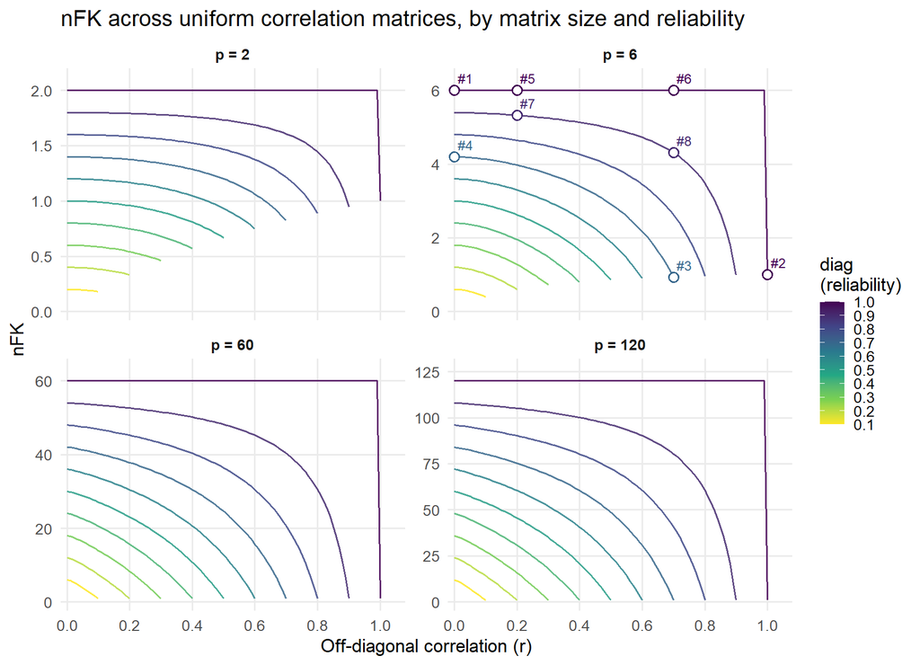